# IE360_Project_RCodes_Group28

## Hour 6

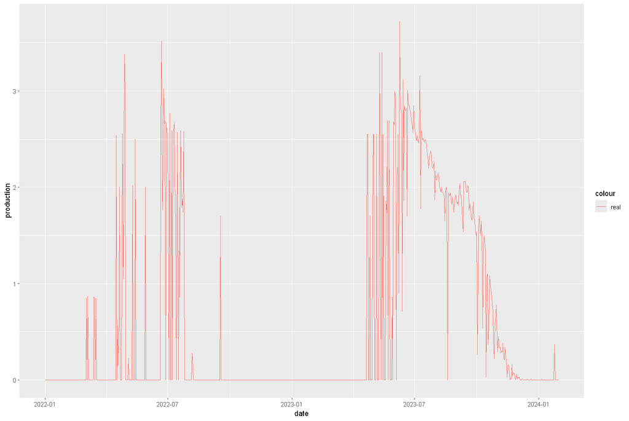

```r
setDT(filtered_data_2)
train_split_data_tables <- split(filtered_data_2, by = "hour")

test_split_data_tables <- split(test_data, by = "hour")

train_hour_6 <- train_split_data_tables[["6"]]
test_hour_6 <- test_split_data_tables[["6"]]

ggplot(train_hour_6,aes(x=date)) + geom_line(aes(y=production,color='real'))
```

Since data is not stationary, we will take differences and build an ARIMA model for it. Important to note here, 1-day difference is not practical for us since the most recent information we have belongs to 2 days ago in the forecasting setting.

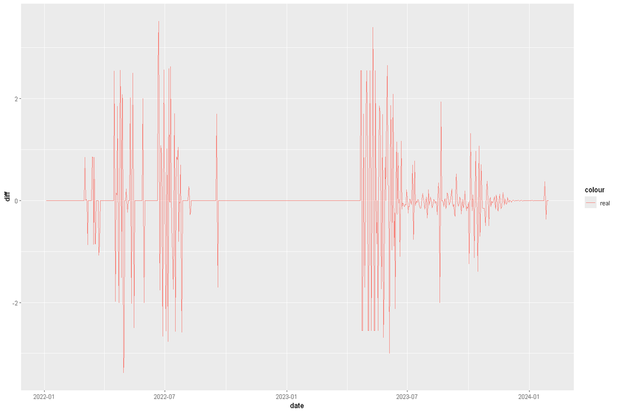

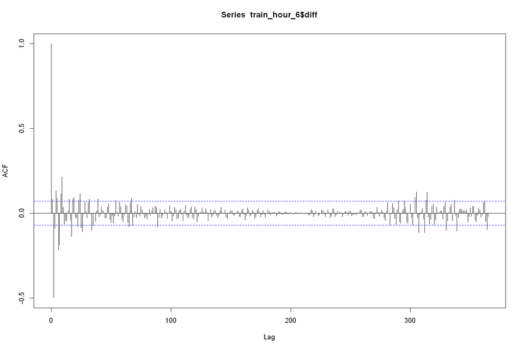

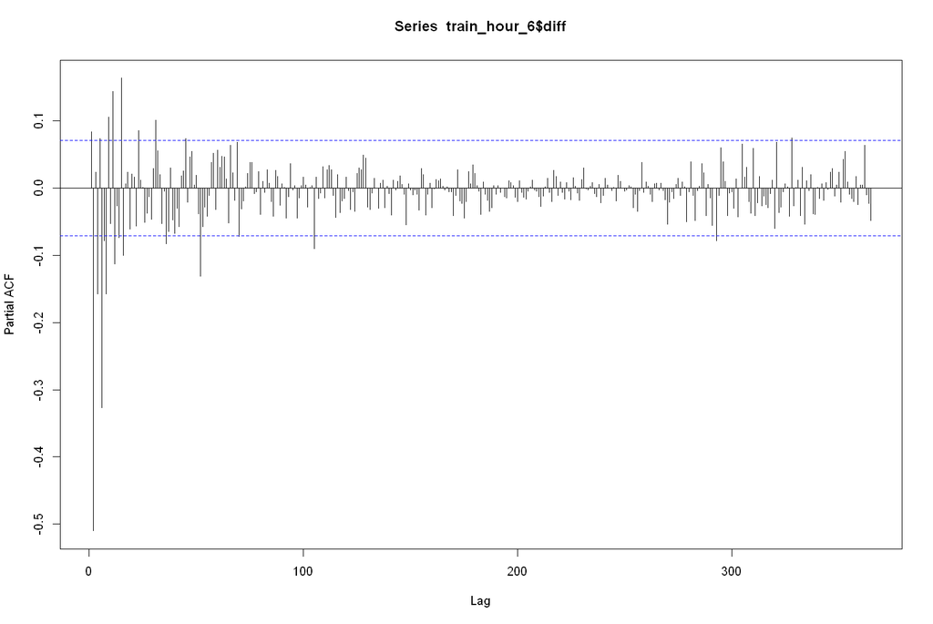

```r
train_hour_6 <- na.omit(train_hour_6)
train_hour_6[,diff:=production - prod_lag_24]

ggplot(train_hour_6,aes(x=date)) + geom_line(aes(y=diff,color='real'))
acf(train_hour_6$diff,lag.max = 365)
pacf(train_hour_6$diff,lag.max = 365)
```

Simple ARIMA Model:

```r
# Fit a simple ARIMA model without external regressors
simple_model <- auto.arima(train_hour_6$diff)
print(summary(simple_model))
```

```
Series: train_hour_6$diff
ARIMA(0,0,3) with zero mean

Coefficients:
         ma1      ma2      ma3
      0.2208  -0.7310  -0.0796
s.e.  0.0360   0.0251   0.0351

sigma^2 = 0.3312:  log likelihood = -655.36
AIC=1318.71   AICc=1318.77   BIC=1337.23

Training set error measures:
                       ME      RMSE       MAE MPE MAPE      MASE         ACF1
Training set -0.006106597 0.5743883 0.2654514 NaN  Inf 0.6350271 0.0004809009
```

ARIMA with regressors:

```r
predictors <- setdiff(names(train_hour_6), c("date", "hour", "production", "diff"))

# Convert predictors to a numeric matrix
predictor_matrix <- as.matrix(train_hour_6[, ..predictors])

# Perform auto.arima
arima_model_regressors <- auto.arima(train_hour_6$diff, xreg = predictor_matrix)

# Summary of the auto.arima model
summary(arima_model_regressors)
```

```
Error in auto.arima(train_hour_6$diff, xreg = predictor_matrix): No suitable ARIMA model found
Traceback:

1. auto.arima(train_hour_6$diff, xreg = predictor_matrix)
2. stop("No suitable ARIMA model found")
```

Since no suitable model is found, we will test with the simple ARIMA model.

```r
train_model <- Arima(train_hour_6$diff, order = c(0, 0, 3))
test_hour_6[,diff:=production - prod_lag_24]

predictions <- numeric(nrow(test_hour_6))

for (i in 1:nrow(test_hour_6)) {
  # Generate forecast for the next step using the model
  forecast_step <- forecast(train_model, h = 1)

  # Store the forecasted value
  predictions[i] <- forecast_step$mean

  new_data <- c(train_hour_6$diff, test_hour_6$diff[1:i])

  # Refit the model to include the new data
  train_model <- auto.arima(new_data)
}

test_hour_6[,predicted:= prod_lag_24 + predictions]
```

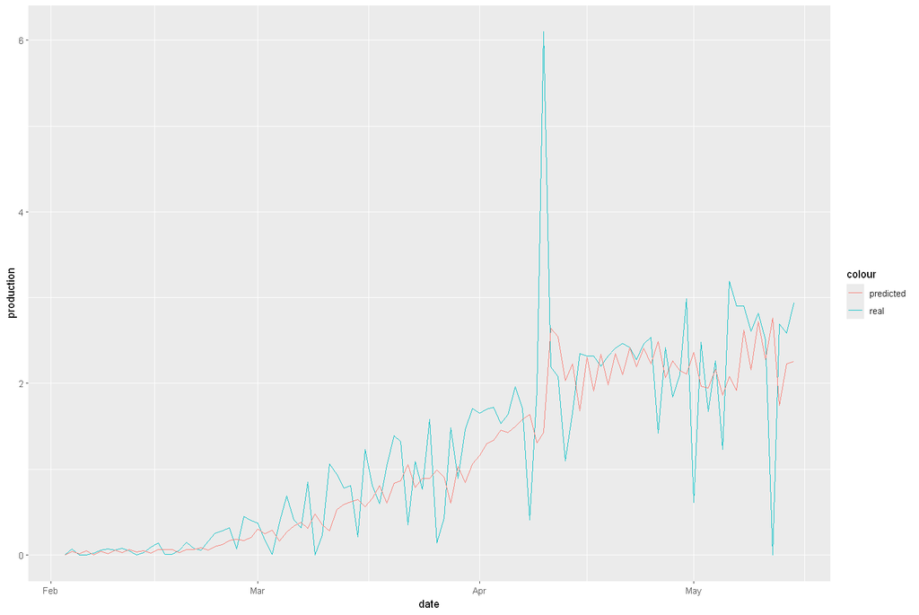

```r
ggplot(test_hour_6,aes(x=date)) + geom_line(aes(y=production,color='real')) + geom_line(aes(y=predicted,color='predicted'))
```

## Hour 7

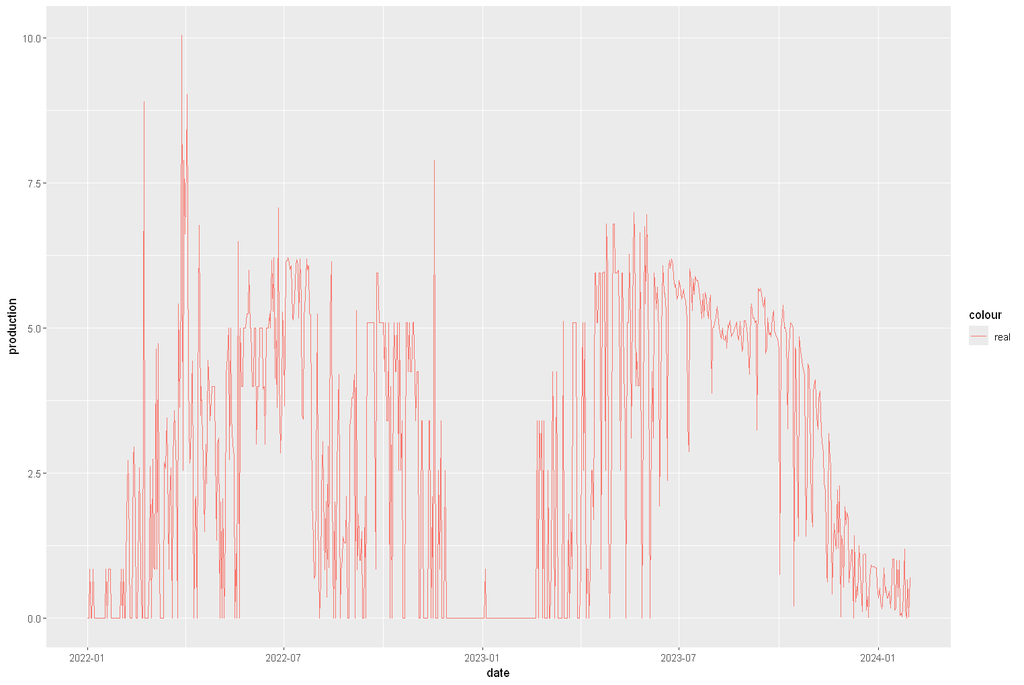

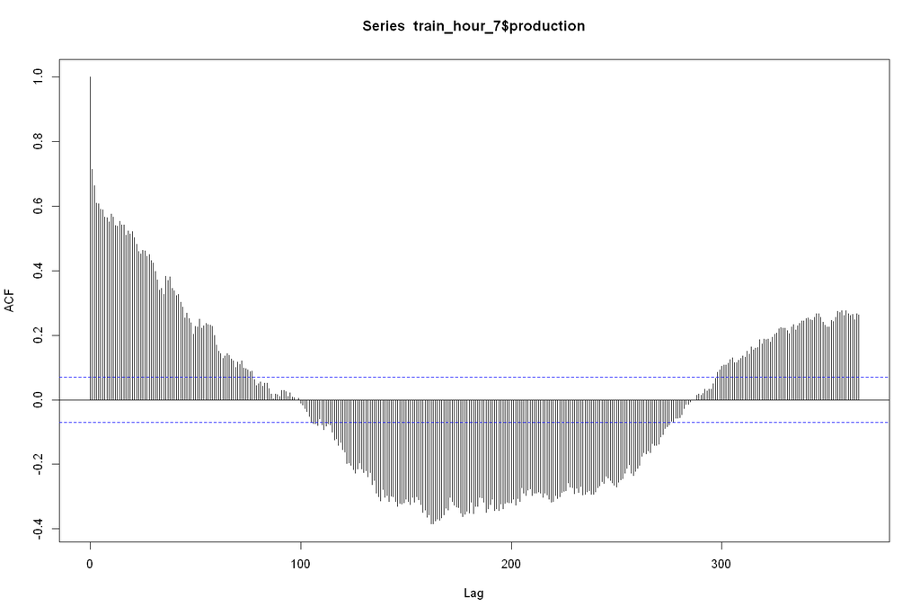

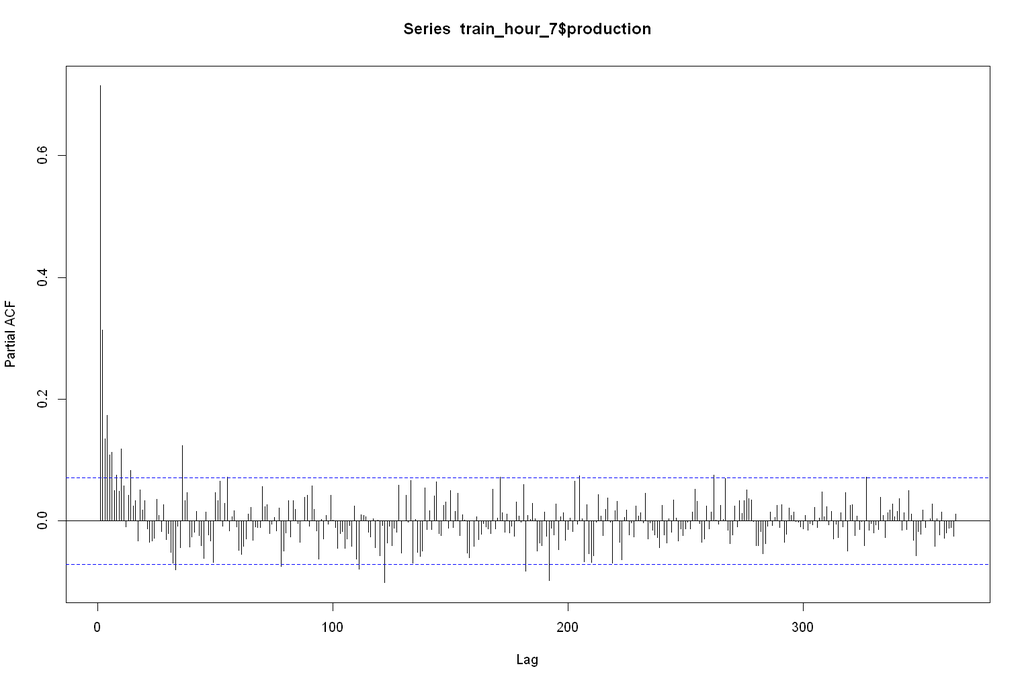

```r
train_hour_7 <- train_split_data_tables[["7"]]
test_hour_7 <- test_split_data_tables[["7"]]

ggplot(train_hour_7,aes(x=date)) + geom_line(aes(y=production,color='real'))
acf(train_hour_7$production,lag.max = 365)
pacf(train_hour_7$production,lag.max = 365)
```